# Combining datasets

Lecture notes

Author

Gilles Guillot, Data Integration Department, World Organisation for Animal Health

Published

September 16, 2025

# 1 Combining datasets into a single table

- It’s rare that a data analysis involves only a single data frame. Typically you have many data frames, and you must join them together to answer the questions that you’re interested in.
- To understand joins, you need to first understand how two tables can be connected through a pair of keys, within each table.
- Every join involves a pair of keys: a primary key and a foreign key. A primary key is a variable or set of variables that uniquely identifies each observation.
- The functions `inner_join()`, `full_join()`, `left_join()`, and `right_join()` are used to combine two data frames based on a common key or set of keys.
- Those functions are able to figure out alone which variable(s) to use as keys, but you can also specify the keys explicitly using the `by` argument.

```r
library(dplyr)

band_members
```

```
# A tibble: 3 × 2
  name  band
  <chr> <chr>
1 Mick  Stones
2 John  Beatles
3 Paul  Beatles
```

```r
band_instruments
```

```
# A tibble: 3 × 2
  name  plays
  <chr> <chr>
1 John  guitar
2 Paul  bass
3 Keith guitar
```

Here it would be convenient to have a single table that contains all the information about each band member, including their name, instrument, and band. However, the information is currently split across two tables: one with the names and bands of the members, and another with the names and instruments of the members.

## 1.1 Full join

`full_join()` returns all rows from both tables, with `NA` in places where there is no match.

```r
full_join(band_members, band_instruments, by = join_by(name))
```

```
# A tibble: 4 × 3
  name  band    plays
  <chr> <chr>   <chr>
1 Mick  Stones  <NA>
2 John  Beatles guitar
3 Paul  Beatles bass
4 Keith <NA>    guitar
```

## 1.2 Inner join

`inner_join()` returns all rows from both tables where there is a match between the keys.

```r
inner_join(band_members, band_instruments, by = join_by(name))
```

```
# A tibble: 2 × 3
  name  band    plays
  <chr> <chr>   <chr>
1 John  Beatles guitar
2 Paul  Beatles bass
```

## 1.3 Left join

`left_join()` returns all rows from the first table, and the matching rows from the second table. If there is no match, `NA` is returned.

```r
left_join(band_members, band_instruments, by = join_by(name))
```

```
# A tibble: 3 × 3
  name  band    plays
  <chr> <chr>   <chr>
1 Mick  Stones  <NA>
2 John  Beatles guitar
3 Paul  Beatles bass
```

## 1.4 Right join

`right_join()` returns all rows from the second table, and the matching rows from the first table. If there is no match, `NA` is returned.

```r
right_join(band_members, band_instruments, by = join_by(name))
```

```
# A tibble: 3 × 3
  name  band    plays
  <chr> <chr>   <chr>
1 John  Beatles guitar
2 Paul  Beatles bass
3 Keith <NA>    guitar
```

## 1.5 Alternative syntax

### 1.5.1 Omitting `by`

With `band_members` and `band_instruments`, there is a variable that uniquely identifies observations in each table: `name`.

The arguemt `by` could have been omitted:

```r
inner_join(band_members, band_instruments)
```

```
# A tibble: 2 × 3
  name  band    plays
  <chr> <chr>   <chr>
1 John  Beatles guitar
2 Paul  Beatles bass
```

### 1.5.2 Piping

You can also use the pipe operator `%>%` to chain together multiple operations. This is particularly useful when you want to perform a series of transformations on a dataset before joining it with another dataset.

```r
band_members %>%
  mutate(band= toupper(band)) %>%
  inner_join(band_instruments, by = join_by(name))
```

```
# A tibble: 2 × 3
  name  band    plays
  <chr> <chr>   <chr>
1 John  BEATLES guitar
2 Paul  BEATLES bass
```

# 2 Grouping and summarising grouped data

Often, datasets consist of several sub-groups. In this case, it is informative to mirror the existence of those sub-groups in the various analyses and plots done.

- Grouping is a powerful feature of `dplyr` that allows you to perform operations on various sub-groups of your data.
- Summarising data is a common task in data analysis, and `dplyr` provides a simple and efficient way to do this: `summarise()`.
- In `dplyr`, the `group_by()` function allows you to group your data by one or more variables, and the `summarise()` function allows you to calculate summary statistics for each group.

For example, if you have a dataset of flights operated by he various airlines, and you want to calculate the average delay for each airline, you can use the `group_by()` function to group the data by airline, and then use the `summarise()` function to calculate the average departure delay for each group.

## 2.1 Example on the mtcars dataset

Remember that the `mtcars` data has the following structure:

```r
mtcars
```

```
                     mpg cyl  disp  hp drat    wt  qsec vs am gear carb
Mazda RX4           21.0   6 160.0 110 3.90 2.620 16.46  0  1    4    4
Mazda RX4 Wag       21.0   6 160.0 110 3.90 2.875 17.02  0  1    4    4
Datsun 710          22.8   4 108.0  93 3.85 2.320 18.61  1  1    4    1
Hornet 4 Drive      21.4   6 258.0 110 3.08 3.215 19.44  1  0    3    1
Hornet Sportabout   18.7   8 360.0 175 3.15 3.440 17.02  0  0    3    2
Valiant             18.1   6 225.0 105 2.76 3.460 20.22  1  0    3    1
Duster 360          14.3   8 360.0 245 3.21 3.570 15.84  0  0    3    4
Merc 240D           24.4   4 146.7  62 3.69 3.190 20.00  1  0    4    2
Merc 230            22.8   4 140.8  95 3.92 3.150 22.90  1  0    4    2
Merc 280            19.2   6 167.6 123 3.92 3.440 18.30  1  0    4    4
Merc 280C           17.8   6 167.6 123 3.92 3.440 18.90  1  0    4    4
Merc 450SE          16.4   8 275.8 180 3.07 4.070 17.40  0  0    3    3
Merc 450SL          17.3   8 275.8 180 3.07 3.730 17.60  0  0    3    3
Merc 450SLC         15.2   8 275.8 180 3.07 3.780 18.00  0  0    3    3
Cadillac Fleetwood  10.4   8 472.0 205 2.93 5.250 17.98  0  0    3    4
Lincoln Continental 10.4   8 460.0 215 3.00 5.424 17.82  0  0    3    4
Chrysler Imperial   14.7   8 440.0 230 3.23 5.345 17.42  0  0    3    4
Fiat 128            32.4   4  78.7  66 4.08 2.200 19.47  1  1    4    1
Honda Civic         30.4   4  75.7  52 4.93 1.615 18.52  1  1    4    2
Toyota Corolla      33.9   4  71.1  65 4.22 1.835 19.90  1  1    4    1
Toyota Corona       21.5   4 120.1  97 3.70 2.465 20.01  1  0    3    1
Dodge Challenger    15.5   8 318.0 150 2.76 3.520 16.87  0  0    3    2
AMC Javelin         15.2   8 304.0 150 3.15 3.435 17.30  0  0    3    2
Camaro Z28          13.3   8 350.0 245 3.73 3.840 15.41  0  0    3    4
Pontiac Firebird    19.2   8 400.0 175 3.08 3.845 17.05  0  0    3    2
Fiat X1-9           27.3   4  79.0  66 4.08 1.935 18.90  1  1    4    1
Porsche 914-2       26.0   4 120.3  91 4.43 2.140 16.70  0  1    5    2
Lotus Europa        30.4   4  95.1 113 3.77 1.513 16.90  1  1    5    2
Ford Pantera L      15.8   8 351.0 264 4.22 3.170 14.50  0  1    5    4
Ferrari Dino        19.7   6 145.0 175 3.62 2.770 15.50  0  1    5    6
Maserati Bora       15.0   8 301.0 335 3.54 3.570 14.60  0  1    5    8
Volvo 142E          21.4   4 121.0 109 4.11 2.780 18.60  1  1    4    2
```

```r
#  summarise() applied to ungrouped tbl returns a single row:
mtcars %>%
  summarise(mean = mean(disp), n = n()) # compute mean and sample size
```

```
      mean  n
1 230.7219 32
```

```r
# Usually, you'll want to group first
mtcars %>%
  group_by(cyl) %>%
  summarise(mean = mean(disp), n = n())
```

```
# A tibble: 3 × 3
    cyl  mean     n
  <dbl> <dbl> <int>
1     4  105.    11
2     6  183.     7
3     8  353.    14
```

## 2.2 Example on the nycflights13 dataset

```r
# install.packages("nycflights13")
library(nycflights13)
flights %>% str
```

```
tibble [336,776 × 19] (S3: tbl_df/tbl/data.frame)
 $ year          : int [1:336776] 2013 2013 2013 2013 2013 2013 2013 2013 2013 2013 ...
 $ month         : int [1:336776] 1 1 1 1 1 1 1 1 1 1 ...
 $ day           : int [1:336776] 1 1 1 1 1 1 1 1 1 1 ...
 $ dep_time      : int [1:336776] 517 533 542 544 554 554 555 557 557 558 ...
 $ sched_dep_time: int [1:336776] 515 529 540 545 600 558 600 600 600 600 ...
 $ dep_delay     : num [1:336776] 2 4 2 -1 -6 -4 -5 -3 -3 -2 ...
 $ arr_time      : int [1:336776] 830 850 923 1004 812 740 913 709 838 753 ...
 $ sched_arr_time: int [1:336776] 819 830 850 1022 837 728 854 723 846 745 ...
 $ arr_delay     : num [1:336776] 11 20 33 -18 -25 12 19 -14 -8 8 ...
 $ carrier       : chr [1:336776] "UA" "UA" "AA" "B6" ...
 $ flight        : int [1:336776] 1545 1714 1141 725 461 1696 507 5708 79 301 ...
 $ tailnum       : chr [1:336776] "N14228" "N24211" "N619AA" "N804JB" ...
 $ origin        : chr [1:336776] "EWR" "LGA" "JFK" "JFK" ...
 $ dest          : chr [1:336776] "IAH" "IAH" "MIA" "BQN" ...
 $ air_time      : num [1:336776] 227 227 160 183 116 150 158 53 140 138 ...
 $ distance      : num [1:336776] 1400 1416 1089 1576 762 ...
 $ hour          : num [1:336776] 5 5 5 5 6 5 6 6 6 6 ...
 $ minute        : num [1:336776] 15 29 40 45 0 58 0 0 0 0 ...
 $ time_hour     : POSIXct[1:336776], format: "2013-01-01 05:00:00" "2013-01-01 05:00:00" ...
```

```r
flights$carrier %>% unique %>% sort
```

```
 [1] "9E" "AA" "AS" "B6" "DL" "EV" "F9" "FL" "HA" "MQ" "OO" "UA" "US" "VX" "WN"
[16] "YV"
```

```r
flights %>%
  group_by(carrier) %>%
  summarise(avg_delay = mean(dep_delay, na.rm = TRUE))
```

```
# A tibble: 16 × 2
   carrier avg_delay
   <chr>       <dbl>
 1 9E          16.7
 2 AA           8.59
 3 AS           5.80
 4 B6          13.0
 5 DL           9.26
 6 EV          20.0
 7 F9          20.2
 8 FL          18.7
 9 HA           4.90
10 MQ          10.6
11 OO          12.6
12 UA          12.1
13 US           3.78
14 VX          12.9
15 WN          17.7
16 YV          19.0
```

# 3 Plotting sub-groups in a dataset

Making a plot mirroring the presence of various sub-groups can be done by using group-specific colors and/or by splitting the plot in various sub-plots. These techniques are illustreated in various examples below.

We remind the generic syntax for plotting with `ggplot2`:

```r
my_data %>% ggplot( aes(...) ) +
  geom_xxx(...) +
  additional_option1(...) +
   additional_option2(...)
```

## 3.1 Various boxplots

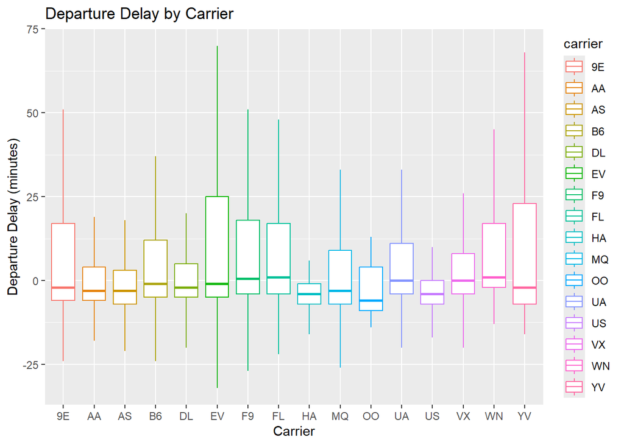

```r
# a boxplot of dep_delay by carrier with jitter points
library(ggplot2)
flights %>% ggplot(aes(x = carrier, y = dep_delay , color= carrier)) +
  geom_boxplot(outliers = FALSE) +
  labs(title = "Departure Delay by Carrier",
       x = "Carrier",
       y = "Departure Delay (minutes)")
```

## 3.2 Overlapping colors

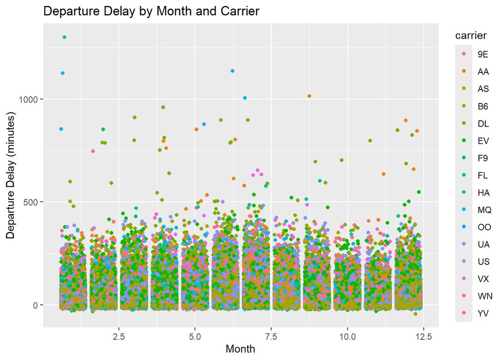

```r
# scatter plot of departure delay against month of the year
flights %>% ggplot(aes(x = month, y = dep_delay, color = carrier)) +
  geom_jitter() +
  labs(title = "Departure Delay by Month and Carrier",
       x = "Month",
       y = "Departure Delay (minutes)")
```

The plot above is unreadable because the points overlap too much. To make it more readable, we can summarise the information by computing the mean departure delay for each carrier and month, and then plot the average delays as a line plot.

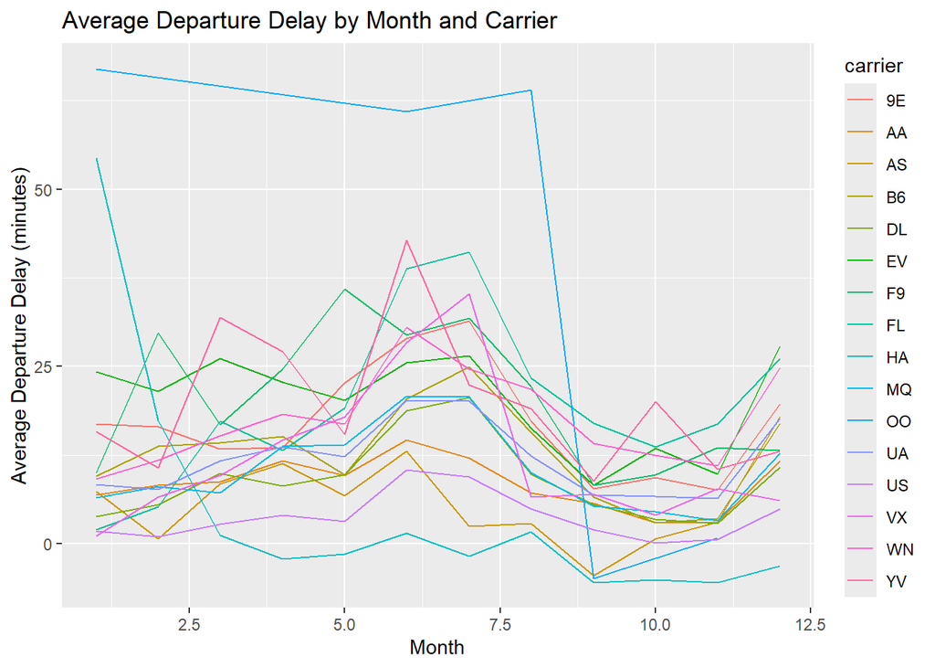

```r
# first group_by() carier and month then compute mean with summarise
flights %>%
  group_by(carrier, month) %>%
  summarise(avg_delay = mean(dep_delay, na.rm = TRUE)) %>%
  ggplot(aes(x = month, y = avg_delay, color = carrier)) +
  geom_line() +
  labs(title = "Average Departure Delay by Month and Carrier",
       x = "Month",
       y = "Average Departure Delay (minutes)")
```

## 3.3 Facetting

Faceting is a powerful feature of `ggplot2` that allows you to create multiple plots based on the values of one or more variables in your dataset. This is particularly useful when you want to compare the variation of a variable across different sub-groups of your data.

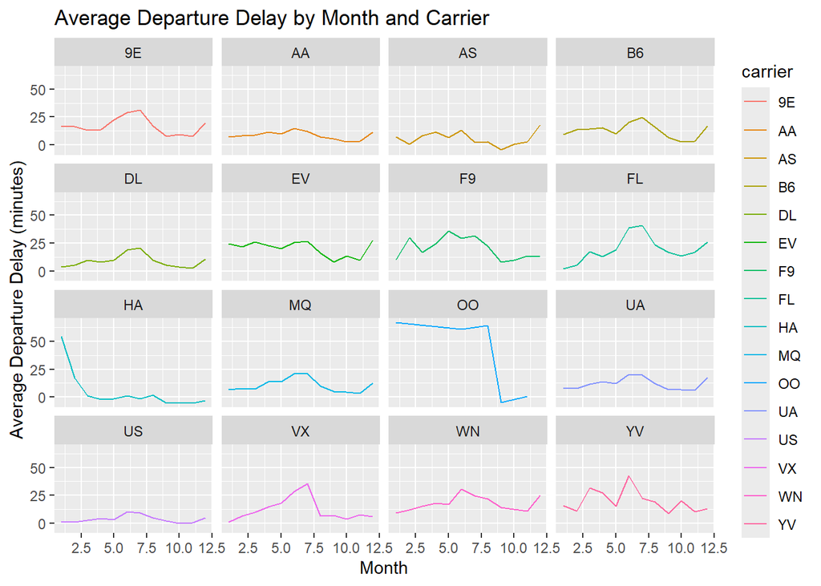

```r
# first group_by() carier and month
# then compute mean with summarise
# then plot the average delays as a line plot with facets by carrier
flights %>%
  group_by(carrier, month) %>%
  summarise(avg_delay = mean(dep_delay, na.rm = TRUE)) %>%
  ggplot(aes(x = month, y = avg_delay, color = carrier)) +
  geom_line() +
  facet_wrap(~ carrier) +
  labs(title = "Average Departure Delay by Month and Carrier",
       x = "Month",
       y = "Average Departure Delay (minutes)")
```

# Assignment

Analysis of chick weight data

# Appendix: session R chunks

```r
# Chunk 1: Load packages or datasets
library(dplyr)

band_members

# Chunk 2: General R code chunk
band_instruments

# Chunk 3: Full join example
full_join(band_members, band_instruments, by = join_by(name))

# Chunk 4: Inner join example
inner_join(band_members, band_instruments, by = join_by(name))

# Chunk 5: Left join example
left_join(band_members, band_instruments, by = join_by(name))

# Chunk 6: Right join example
right_join(band_members, band_instruments, by = join_by(name))

# Chunk 7: Inner join example
inner_join(band_members, band_instruments)

# Chunk 8: Inner join example
band_members %>%
  mutate(band= toupper(band)) %>%
  inner_join(band_instruments, by = join_by(name))

# Chunk 9: Display mtcars dataset
mtcars

# Chunk 10: Summarise ungrouped mtcars
#  summarise() applied to ungrouped tbl returns a single row:
mtcars %>%
  summarise(mean = mean(disp), n = n()) # compute mean and sample size

# Chunk 11: Summarise mtcars by cyl
# Usually, you'll want to group first
mtcars %>%
  group_by(cyl) %>%
  summarise(mean = mean(disp), n = n())

# Chunk 12: Install and summarise flights dataset
# install.packages("nycflights13")
library(nycflights13)
flights %>% str

flights$carrier %>% unique %>% sort

flights %>%
  group_by(carrier) %>%
  summarise(avg_delay = mean(dep_delay, na.rm = TRUE))

# Chunk 13: Generic ggplot syntax template
my_data %>% ggplot( aes(...) ) +
  geom_xxx(...) +
  additional_option1(...) +
   additional_option2(...)

# Chunk 14: Boxplot of delays by carrier
# a boxplot of dep_delay by carrier with jitter points
library(ggplot2)
flights %>% ggplot(aes(x = carrier, y = dep_delay , color= carrier)) +
  geom_boxplot(outliers = FALSE) +
  labs(title = "Departure Delay by Carrier",
       x = "Carrier",
       y = "Departure Delay (minutes)")

# Chunk 15: Scatterplot of delay vs month
# scatter plot of departure delay against month of the year
flights %>% ggplot(aes(x = month, y = dep_delay, color = carrier)) +
  geom_jitter() +
  labs(title = "Departure Delay by Month and Carrier",
       x = "Month",
       y = "Departure Delay (minutes)")

# Chunk 16: Line plot of average delays
# first group_by() carier and month then compute mean with summarise
flights %>%
  group_by(carrier, month) %>%
  summarise(avg_delay = mean(dep_delay, na.rm = TRUE)) %>%
  ggplot(aes(x = month, y = avg_delay, color = carrier)) +
  geom_line() +
  labs(title = "Average Departure Delay by Month and Carrier",
       x = "Month",
       y = "Average Departure Delay (minutes)")

# Chunk 17: Faceted line plot of average delays
# first group_by() carier and month
# then compute mean with summarise
# then plot the average delays as a line plot with facets by carrier
flights %>%
  group_by(carrier, month) %>%
  summarise(avg_delay = mean(dep_delay, na.rm = TRUE)) %>%
  ggplot(aes(x = month, y = avg_delay, color = carrier)) +
  geom_line() +
  facet_wrap(~ carrier) +
  labs(title = "Average Departure Delay by Month and Carrier",
       x = "Month",
       y = "Average Departure Delay (minutes)")
```